# Project6

bigMACs

2022-11-06

### Methods

#### Image Acquisition

Images analyzed in this project were acquired by downloading the R package, rgif, which permits access to the Global Biodiversity Information Facility’s (GBIF) application programming interface. Records from GBIF were now accessible for all Lepidoptera analyzed below.

#### Digitization

Right-wing shapes across ~200 species of Lepidoptera were examined utilizing the image analysis program FIJI. After opening each image, the following sequence was followed depending on scale bar, wing damage, and hindwing exposure. If a scale bar was present, the scale was set in mm. If the right-wing pair was damaged, the image was flipped horizontally. The wings were then traced utilizing the polygon selection tool. A script was created, and the selected points (x and y coordinates) were exported in a .txt file for further analysis.

#### Shape & Comparative Analysis

Outline-based shape analysis, utilizing Elliptical Fourier Analysis (EFA) and Principal Components Analysis (PCA), were performed to compare shape change between species. PCA plot output for both forewing and hindwing can be referenced below (Figures 1 & 2). Evolutionary rates of the PC scores were observed across the Lepidoptera tree (Kawahara et al. 2019) and species information was added (Figure 3).

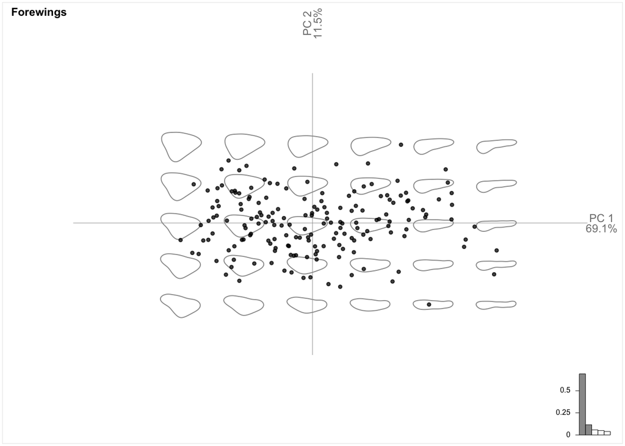

Figure 1: Biplot visualization of PCA 1 and 2 in the forewings

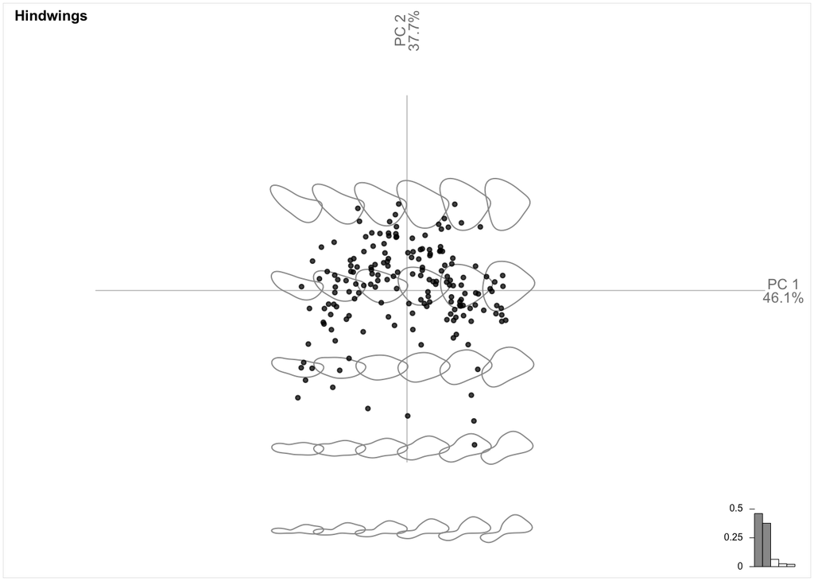

Figure 2: Biplot visualization of PCA 1 and 2 in the hindwings

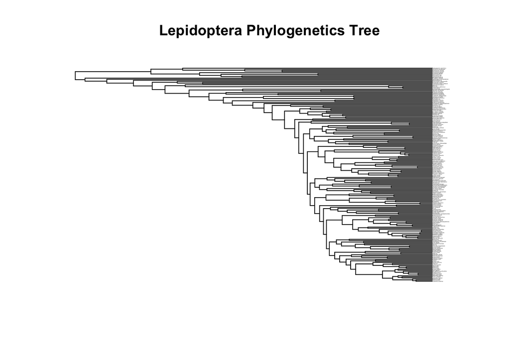

Figure 3: Phylogenetic tree based on Kawahara et al. (2019) study on Lepidoptera. The same tree is modified to include only species observed in PC analysis and merged with PC data to visualize evolutionary rate shifts

#### Evolutionary Rates & Shifts

The “non-censored test” (O’Meara et al. 2006) was utilized to estimate the rates of morphological evolution over a phylogenetic tree. Phylogenetic ridge regression (Kratsch and McHardy 2014) was then utilized to determine whether the evolutionary shift was to a slower or faster rate. The regressions are based on the phenotype values at each node vs. time between nodes and along the path. The value of the slope parameter of these regressions is the rate.

#### Shape Evolution Correlation

Phylogenetic independent contrasts (PIC) analysis was performed to investigate the correlation in hind and forewing shape evolution. R-squared values were then found by creating a linear model.

### Results

#### Evolutionary Rates: Hindwing vs. Forewing

##### Evolution Rate Estimate of PC1 in Forewing

```
## [1] 0.006535527
```

##### Evolution Rate Estimate of PC2 in Forewing

```
## [1] 0.002411568
```

##### Evolution Rate Estimate of PC1 in Hindwing

```
## [1] 0.01014157
```

##### Evolution Rate Estimate of PC2 in Hindwing

```
## [1] 0.01870921
```

The evolutionary rates of the forewing and hindwing are quite different. The hindwing seems to evolve at a rate almost twice as fast as the forewing. The PC1 rates show the forewing to be undergoing evolutionary shifts at a rate of 0.006535527 versus the rate of 0.01014157 in the hindwing. This suggests the hindwing changes are occuring much more frequently in size and shape to promote advantageous factors in the Lepodoptra.The PC2 as well shows a large increase in evolutionary rates in the hindwing.

#### Shifts in Evolutionary Rates

##### Hindwing PC1

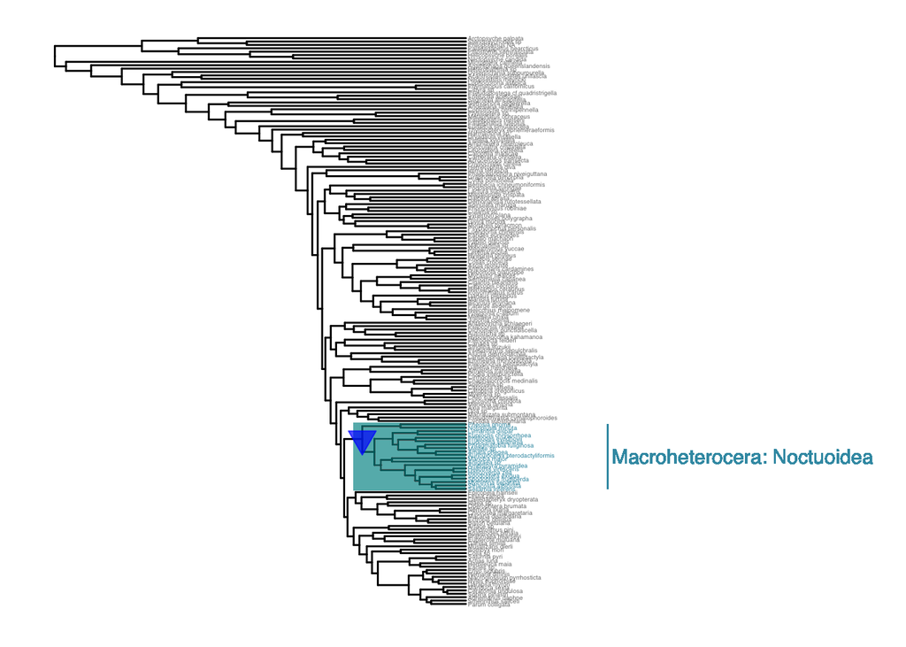

Figure 4: Visualization of evolutionary rate shift in the hindwings’ PC1. Blue and downwards arrow indiactes a significant low rate shift. The table below shows the rate difference compared to the rest of the tree and the significance of the difference

```
## # A tibble: 1 × 4
##       n rate.difference p.value clade
##   <dbl>           <dbl>   <dbl> <chr>
## 1   225        -0.00194   0.001 Macroheterocera: Noctuoidea
```

##### Hindwing PC2

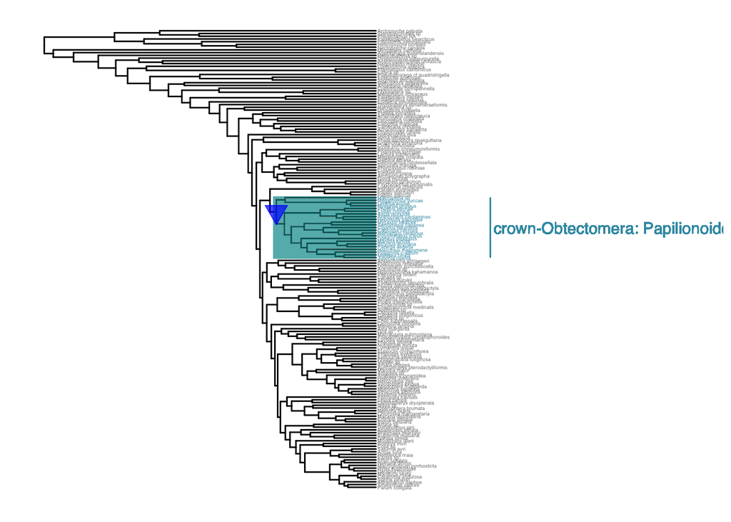

Figure 5: Visualization of evolutionary rate shift in the hindwings’ PC2. Blue and downwards arrow indiactes a significant low rate shift. The table below shows the rate difference compared to the rest of the tree and the significance of the difference

```
## # A tibble: 1 × 4
##       n rate.difference p.value clade
##   <dbl>           <dbl>   <dbl> <chr>
## 1   271        -0.00161   0.001 crown-Obtectomera: Papilionoidea
```

##### Forewing PC1

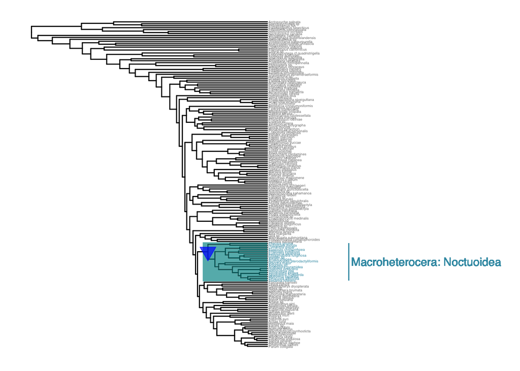

Figure 6: Visualization of evolutionary rate shift in the forewings’ PC1. Blue and downwards arrow indiactes a significant low rate shift. The table below shows the rate difference compared to the rest of the tree and the significance of the difference

```
## # A tibble: 1 × 4
##       n rate.difference p.value clade
##   <dbl>           <dbl>   <dbl> <chr>
## 1   225        -0.00162   0.001 Macroheterocera: Noctuoidea
```

##### Forewing PC2

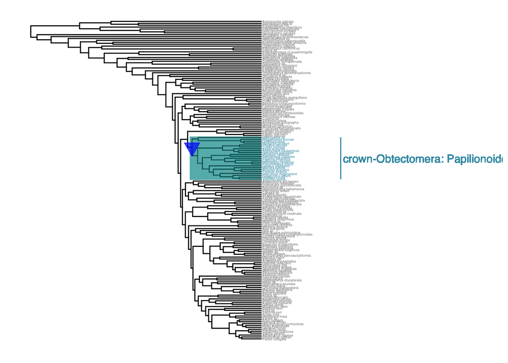

Figure 7: Visualization of evolutionary rate shift in the forewings’ PC2. Blue and downwards arrow indiactes a significant low rate shift. The table below shows the rate difference compared to the rest of the tree and the significance of the difference

```
## # A tibble: 1 × 4
##       n rate.difference p.value clade
##   <dbl>           <dbl>   <dbl> <chr>
## 1   271        -0.00161   0.001 crown-Obtectomera: Papilionoidea
```

#### Shape Evolution Correlation

##### Predictors of hindwing PC1

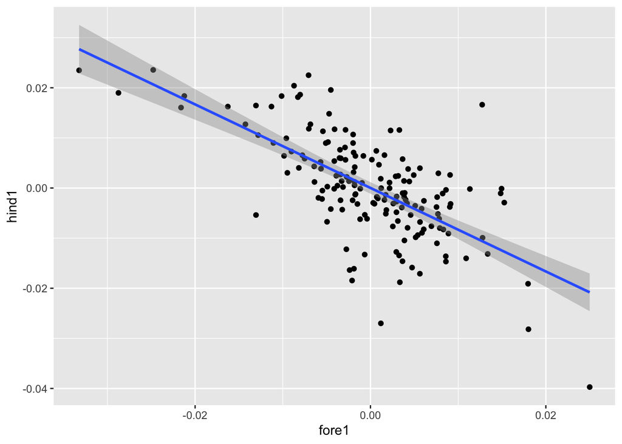

Figure 8: Linear regression plot of the dependent variable, hindwing PC1, against the independent variable, forewing PC1

The linear regression plot indicates a strong, negative correlation between PC1 of forewing and hindwing.

```
##
## Call:
## lm(formula = hind1 ~ fore1, data = PC.pic)
##
## Residuals:
##        Min         1Q     Median         3Q        Max
## -0.0260329 -0.0040299 -0.0001764  0.0048320  0.0272273
##
## Coefficients:
##               Estimate Std. Error t value Pr(>|t|)
## (Intercept)  1.629e-05  5.845e-04   0.028    0.978
## fore1       -8.335e-01  7.209e-02 -11.562   <2e-16 ***
## ---
## Signif. codes:  0 '***' 0.001 '**' 0.01 '*' 0.05 '.' 0.1 ' ' 1
##
## Residual standard error: 0.007552 on 165 degrees of freedom
## Multiple R-squared:  0.4476, Adjusted R-squared:  0.4442
## F-statistic: 133.7 on 1 and 165 DF,  p-value: < 2.2e-16
```

The results from the plot is supported by linear model above. The negative relationship is statistically significant at near 0% level, with a t-value of -11.562. The adjusted R-squared value of 0.4442 also indicates a single variable in PC1 of the forewing is enough to account for a significant amount of variance in the PC1 of the hindwing.

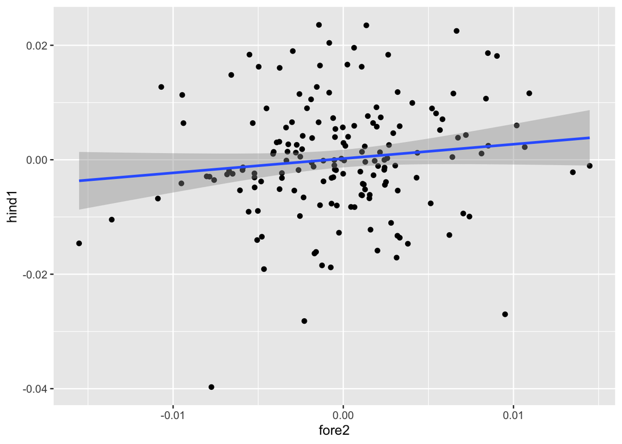

Figure 9: Linear regression plot of the dependent variable, hindwing PC1, against the independent variable, forewing PC2

In contrast with Figure 8, the positive relationship between hindwing PC1 and forewing PC2 is not as clear and significant.

```
##
## Call:
## lm(formula = hind1 ~ fore2, data = PC.pic)
##
## Residuals:
##       Min        1Q    Median        3Q       Max
## -0.037987 -0.004883 -0.000580  0.005510  0.023717
##
## Coefficients:
##             Estimate Std. Error t value Pr(>|t|)
## (Intercept) 0.000208   0.000781   0.266    0.790
## fore2       0.250193   0.158564   1.578    0.117
##
## Residual standard error: 0.01008 on 165 degrees of freedom
## Multiple R-squared:  0.01486,    Adjusted R-squared:  0.008894
## F-statistic:  2.49 on 1 and 165 DF,  p-value: 0.1165
```

As expected from Figure 9, the correlation is weak and insignificant at any alpha level. An extremely large amount of variance in the hindwings’ PC1 is not explained by forewing PC2, as indicated by the low R-squared values.

```
##
## Call:
## lm(formula = hind1 ~ fore1 + fore2, data = PC.pic)
##
## Residuals:
##        Min         1Q     Median         3Q        Max
## -0.0276811 -0.0035985 -0.0001156  0.0045246  0.0270744
##
## Coefficients:
##               Estimate Std. Error t value Pr(>|t|)
## (Intercept)  5.074e-05  5.832e-04   0.087    0.931
## fore1       -8.274e-01  7.199e-02 -11.493   <2e-16 ***
## fore2        1.690e-01  1.186e-01   1.425    0.156
## ---
## Signif. codes:  0 '***' 0.001 '**' 0.01 '*' 0.05 '.' 0.1 ' ' 1
##
## Residual standard error: 0.007528 on 164 degrees of freedom
## Multiple R-squared:  0.4543, Adjusted R-squared:  0.4477
## F-statistic: 68.27 on 2 and 164 DF,  p-value: < 2.2e-16
```

```
##
## Call:
## lm(formula = hind1 ~ fore1 * fore2, data = PC.pic)
##
## Residuals:
##        Min         1Q     Median         3Q        Max
## -0.0278353 -0.0035587 -0.0001356  0.0045347  0.0267401
##
## Coefficients:
##               Estimate Std. Error t value Pr(>|t|)
## (Intercept)  9.798e-05  5.831e-04   0.168    0.867
## fore1       -8.094e-01  7.318e-02 -11.060   <2e-16 ***
## fore2        1.542e-01  1.189e-01   1.297    0.196
## fore1:fore2  2.009e+01  1.553e+01   1.294    0.197
## ---
## Signif. codes:  0 '***' 0.001 '**' 0.01 '*' 0.05 '.' 0.1 ' ' 1
##
## Residual standard error: 0.007513 on 163 degrees of freedom
## Multiple R-squared:  0.4599, Adjusted R-squared:  0.4499
## F-statistic: 46.26 on 3 and 163 DF,  p-value: < 2.2e-16
```

The two linear models above summarize the effects of PC1 and PC2 of the forewing on PC1 of the hindwing in a multivariate context. In both cases, forewing PC1 maintained its statistical significance and forewing PC2 maintained its insignificance. The low t-value of the interaction term also suggest that PC1 and PC2 of the forewing do not influence each others’ effects on hindwing PC1. Since there is also no significant change in the R-squared values from that in Figure 8, the linear model with only forewing PC1 would be the best and most straightforward predictor for hindwing PC1.

##### Predictors of hindwing PC2

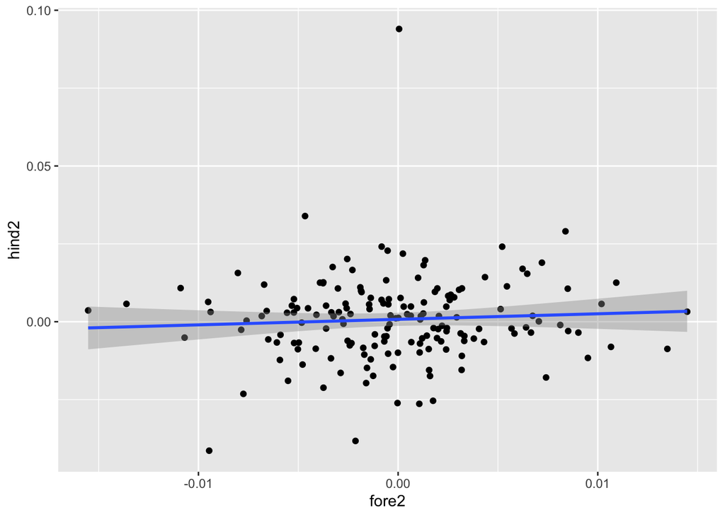

Figure 10: Linear regression plot of the dependent variable, hindwing PC2, against the independent variable, forewing PC2

```
##
## Call:
## lm(formula = hind2 ~ fore2, data = PC.pic)
##
## Residuals:
##       Min        1Q    Median        3Q       Max
## -0.040493 -0.007104  0.000357  0.006907  0.093219
##
## Coefficients:
##              Estimate Std. Error t value Pr(>|t|)
## (Intercept) 0.0007655  0.0010652   0.719    0.473
## fore2       0.1778140  0.2162627   0.822    0.412
##
## Residual standard error: 0.01375 on 165 degrees of freedom
## Multiple R-squared:  0.00408,    Adjusted R-squared:  -0.001955
## F-statistic: 0.676 on 1 and 165 DF,  p-value: 0.4121
```

The linear model visualized in Figure 10 indicate that PC2 of the forewing is not a statistically significant predictor of PC2 of the hindwing. The slope coefficient is also relatively weak.

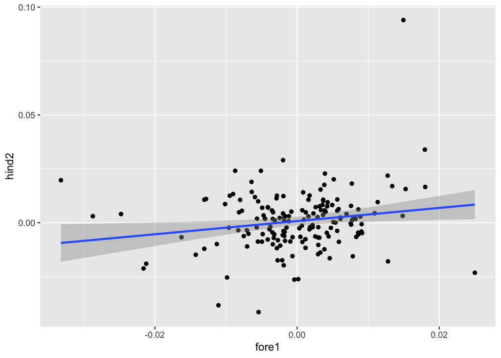

Figure 11: Linear regression plot of the dependent variable, hindwing PC2, against the independent variable, forewing PC1

```
##
## Call:
## lm(formula = hind2 ~ fore1, data = PC.pic)
##
## Residuals:
##       Min        1Q    Median        3Q       Max
## -0.040536 -0.007717 -0.000820  0.006485  0.088646
##
## Coefficients:
##              Estimate Std. Error t value Pr(>|t|)
## (Intercept) 0.0007825  0.0010492   0.746   0.4569
## fore1       0.3053713  0.1293947   2.360   0.0194 *
## ---
## Signif. codes:  0 '***' 0.001 '**' 0.01 '*' 0.05 '.' 0.1 ' ' 1
##
## Residual standard error: 0.01356 on 165 degrees of freedom
## Multiple R-squared:  0.03265,    Adjusted R-squared:  0.02679
## F-statistic:  5.57 on 1 and 165 DF,  p-value: 0.01944
```

According to Figure 11, forewing PC1 appears to be a slightly better predictor of hindwing PC2. The linear model shows that the positive relationship is statistically significant at the 5 percent level.

```
##
## Call:
## lm(formula = hind2 ~ fore2 + fore1, data = PC.pic)
##
## Residuals:
##       Min        1Q    Median        3Q       Max
## -0.038565 -0.007651 -0.000498  0.006616  0.088481
##
## Coefficients:
##             Estimate Std. Error t value Pr(>|t|)
## (Intercept) 0.000825   0.001050   0.786   0.4333
## fore2       0.208524   0.213547   0.976   0.3303
## fore1       0.312914   0.129643   2.414   0.0169 *
## ---
## Signif. codes:  0 '***' 0.001 '**' 0.01 '*' 0.05 '.' 0.1 ' ' 1
##
## Residual standard error: 0.01356 on 164 degrees of freedom
## Multiple R-squared:  0.03824,    Adjusted R-squared:  0.02652
## F-statistic: 3.261 on 2 and 164 DF,  p-value: 0.04086
```

```
##
## Call:
## lm(formula = hind2 ~ fore2 * fore1, data = PC.pic)
##
## Residuals:
##       Min        1Q    Median        3Q       Max
## -0.036655 -0.007706 -0.000187  0.006552  0.089043
##
## Coefficients:
##               Estimate Std. Error t value Pr(>|t|)
## (Intercept)  7.445e-04  1.051e-03   0.709   0.4796
## fore2        2.337e-01  2.142e-01   1.091   0.2769
## fore1        2.823e-01  1.319e-01   2.141   0.0338 *
## fore2:fore1 -3.422e+01  2.798e+01  -1.223   0.2231
## ---
## Signif. codes:  0 '***' 0.001 '**' 0.01 '*' 0.05 '.' 0.1 ' ' 1
##
## Residual standard error: 0.01354 on 163 degrees of freedom
## Multiple R-squared:  0.04699,    Adjusted R-squared:  0.02945
## F-statistic: 2.679 on 3 and 163 DF,  p-value: 0.04879
```

In a multivariate context, the relationships of forewing PC1 and PC2 with hindwing PC2 do not change. There also is no significant interaction. As a summary, there is a very strong and significant negative relationship between hindwing PC1 and forewing PC1. There is also a relatively significant positive relationship between hindwing PC2 and forewing PC1. The shape of the hingwing is therefore correlated with the shape of the forewing to a certain extent.

### Contributions

*Jack: Introduction, methods, and bibliography

*John: Introduction, results, and bibliography

*Philip: Markdown file formatting, R-script coding, results

*Samantha: Discussion

### References

Jantzen, Benjamin, and Thomas Eisner. 2008. “Hindwings Are Unnecessary for Flight but Essential for Execution of Normal Evasive Flight in Lepidoptera.” *Proceedings of the National Academy of Sciences* 105 (43): 16636–40.

Kawahara, Akito Y, David Plotkin, Marianne Espeland, Karen Meusemann, Emmanuel FA Toussaint, Alexander Donath, France Gimnich, et al. 2019. “Phylogenomics Reveals the Evolutionary Timing and Pattern of Butterflies and Moths.” *Proceedings of the National Academy of Sciences* 116 (45): 22657–63.

Kratsch, Christina, and Alice C McHardy. 2014. “RidgeRace: Ridge Regression for Continuous Ancestral Character Estimation on Phylogenetic Trees.” *Bioinformatics* 30 (17): i527–33.

O’Meara, Brian C, Cécile Ané, Michael J Sanderson, and Peter C Wainwright. 2006. “Testing for Different Rates of Continuous Trait Evolution Using Likelihood.” *Evolution* 60 (5): 922–33.